# Twitter

My goal is to provide traders decipherable metrics in the cryptocurrency market. I try not to influence people’s financial decisions, make calls/predictions, or share my opinions on which coin is better than others.

## 1. Features on Twitter

### 1.1 The Dip Index @BitcoinDips.

Two items are posted periodically on **BuyTheDips** [**@BitcoinDips**](https://twitter.com/bitcoindips).

1. **NO LONGER POSTS JPEGS**. Current cryptocurrency prices are fetched from both coinmarketcap & coingecko via API every 20 minutes ([example](https://ahjustsea.github.io/BuyTheDip/tmpplot.jpeg)). Z-scores are posted every hour unless when large dips/moons are happening, z > 2.0 or z < -2.0, the results are posted immediately. Bitcoin Z-score is always posted at the top, followed by other cryptocurrencies. The frequency will change with future updates. Both cryptocurrency databases are used to ensure accuracy as BNB prices on coinmarkcap are sometimes inflated.
2. 24-hour trends as .gif animations are posted three times a day: 11:30am, 7:30pm and 3:30am EST. ([example](https://ahjustsea.github.io/BuyTheDip/dailyz.gif)).

### **MOLE HAS BEEN TAKEN OFFLINE**

### 1.2 Mole, The Connoisseur of Flavourful Dips, @BitcoinDipsMole

Current status: **Mole** [**@BitcoinDipsMole**](https://twitter.com/bitcoindipsMole) is live! (Birthdate: Oct 27th, 2021).

Going to bed? Stepping out for dinner? Kids crying their eyes out? **Mole** [@bitcoindipsMole](https://twitter.com/bitcoindipsMole) is here to help! Mole gives suggestions for limit buys based on z-scores so that you can catch large dips while you are away from the computer. For Mole to respond, you have to follow [@bitcoindips](https://twitter.com/bitcoindips).

#### 1.2.1 How to call Mole

[figure not shown]

##### Function 1: To get dip levels,

- tweet *“@bitcoindips !getdips $SYMBOL”*.

For example, tweet *“@bitcoindips !getdips $BTC”* to get bitcoin suggestions. If you try calling more than one symbol, only the first will be used.

- **Level 1 favourless dip** = **Ketcup**. What the price (USD) would be if z-score dropped to **-1**. Please note that z score of -1 is NOT a statistically significant dip.
- **Level 2 good dip** = **Hummus**. What the price (USD) would be if z-score dropped to **-2**.
- **Level 3 great dip** = **Tzatziki**. What the price (USD) would be if z-score dropped to **-3**.
- **Level 4 exquisite dip** = **Guacamole**. What the price (USD) would be if z-score dropped to **-4**.
- **Level 5 heavenly dip** = **Fondue**. What the price (USD) would be if z-score dropped to **-5**.
- $SYMBOLS currently supported: **$BTC**, **$ETH**, **$DOGE**, **$SHIB**, **$BNB**, **$ADA**, **$XRP**, **$DOT**, **$SOL**, **$MATIC**, **$MOON**, **$LTC**, **$GRT**, **$FTM**,

##### Function 2: *(WARNING, ONLY FOR AGGRESSIVE INVESTORS)* To get dip levels that will fill sooner,

- tweet *“@bitcoindips !getspicy $SYMBOL”*.

This differs from the previous function in one aspect: Dips are calculated from current prices rather than moving day averages. These dips are risky in that *they’re NOT statistically true dips*. To be used when you want to get on a coin that’s trending up, but don’t want to FOMO at sell order prices.

- **Level 1 no spice dip** = **Ajvar**. What the price (USD) would be if z-score dropped to **-1** from current prices.
- **Level 2 mild spice dip** = **Cajun**. What the price (USD) would be if z-score dropped to **-1.5** from current prices.
- **Level 3 medium dip** = **Tabasco**. What the price (USD) would be if z-score dropped to **-2** from current prices.
- **Level 4 hot dip** = **Jerk**. What the price (USD) would be if z-score dropped to **-2.5** from current prices.
- **Level 5 very hot dip** = **Sambal**. What the price (USD) would be if z-score dropped to **-3** from current prices.
- $SYMBOLS currently supported: **$BTC**, **$ETH**, **$DOGE**, **$SHIB**, **$BNB**, **$ADA**, **$XRP**, **$DOT**, **$SOL**, **$MATIC**, **$MOON**, **$LTC**, **$GRT**, **$FTM**,

##### Function 3: To get suggestions on what’s dipping,

- tweet *“@bitcoindips !HeyMole whats good?”*.

Mole will suggest what are currently good dips based on z-scores (Also functional: “what’s tasty?”). Mole will not suggest any cryptocurrencies (coins/tokens) from the deep depths of smart contracts. Mole has been studying specific cryptocurrencies in great detail for the last 6 months, and will not tell you that something is good when it is not. In other words, Mole will never shill very low marketcap cryptos (e.g., shitcoins). This is not to say that you can’t make money off these coins, it’s just that Mole doesn’t feel comfortable talking about them. You can trust Mole as much as you trust your mathematician.

#### 1.2.2 Mole’s Q&A:

- **How long does Mole take to answer?** Mole should get back to you within 2 minutes. If not, please let Mole know so errors can be tracked down and fixed!
- **Why are Mole’s suggestions really low?** This happens when the crypto has pumped significantly in the last two weeks (and could be still pumping), so statistically significant dips are soooo far away. In this case, you may try $getspicy instead of $getdips. As stated in the warning above, it’s pretty aggressive. But it’s up to you.
- **Why does one of the dips say “$zero”?** It essential means that the price of the coin is volatile (very dramatic pumps in the last two weeks). In this case, it means that if this crypto ever reaches that level of dip, it’s essentially crashed to zero.
- **Mole cannot reply to protected tweets!**. In this case, please change your twitter settings to access Mole.
- **I did everything right and Mole still hasn’t answered!** To prevent some spam attacks, Mole will only respond to accounts with at least one follower (Sorry). Or something has gone wrong. Please let me know!
- **Please be sensible towards calling Mole.** In the best case scenario, Mole will slow down and crash. In the worst case, Mole will get banned from Twitter.*

## 2. Brief explanation on BuyTheDips Metrics

### 2.1 z-scores based on **price** (aka z-price).

z-scores are current price metric calculated from trading volume-adjusted two-week moving averages and standard deviations.

1. Z-score greater than **+2** means that the current price is significantly **HIGHER** than what’s expected from the last two weeks. In this case, *you may consider* **selling*** some coins to take some profits* assuming that your average cost per coin is lower than the current price. If you’re looking to buy at z-score > 2, you will be paying a premium.
2. Z-score less than **-2** means that the current price is significantly **LOWER** than what’s expected from the last two weeks. In this case, *you may consider* **buying*** more coins as it is a good time to buy*, and prices may go back to norm.
3. Z-score between +2 and -2 means that the current price is very similar to the average price of last two weeks. In other words, the price is **fair**.

### 2.2 All this is cool but does following z-scores work?

- Surprisingly yes, it works pretty well but you have to be disciplined to some extend. Buying cryptos when z-scores are less than -2 or -3 can make you 6-20% additional returns on your investment.
- Detailed information on how BuyTheDips makes more on your investment can be found [**here**](http://buythedips.io/zscore_investing.html).

[output not shown]

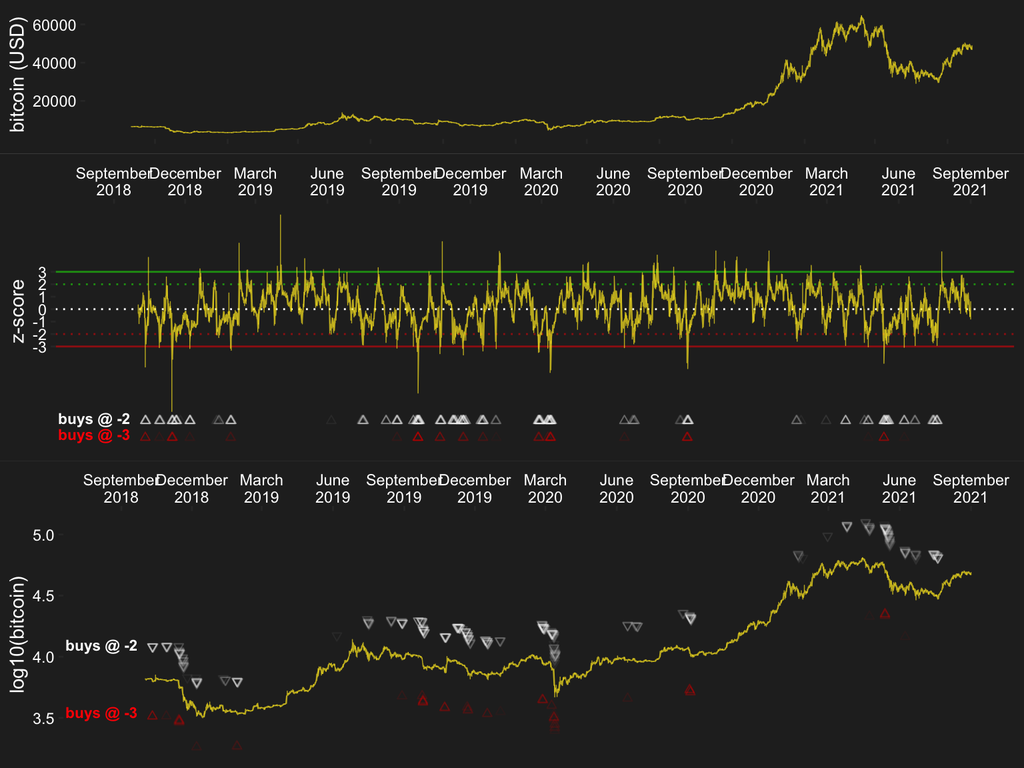

## 3. Reach out for suggestions

- You can find me on reddit (u/Ahjustsea) or on twitter (@bitcoinDips).
- If you would like to support BuyTheDips, you can make a donation below. Any support will be greatly appreciated. Thank you!

**BTC**: bc1qcay52dwm8h7qugj4tkzjcg0wrzhqf9jsh62sgn

**ETH**: 0xA1e608C40C88B83e3325a9f25E0523BE8bC977d2

**ADA**: Ae2tdPwUPEZMc9Jp6RVE4SfCKpQCQD4LMZKiSaoyCtSzTE5JNrZNrvBiyTT

**SOL**: 8oETiSiMJhR1iMSPqWQDZ24qhToxfdBZHG5AP9Jfimv6

**XLM**: GBC7BWLJ7LPGZGNSBOQQAGA4IQB3OINZ3WT7FHUQ3XRAWFJQC56X34XL

**USDT**: 0xA1e608C40C88B83e3325a9f25E0523BE8bC977d2

**DOGE**: DKwBg5xx946AMYrSQL1ZecGazetWHRe7Rs

**SHIB**: 0xA1e608C40C88B83e3325a9f25E0523BE8bC977d2

**r/cc MOON**: 0x1a5fce959e9e6574cba3893f9d3abcc127d8c82b